# NFL Offense Salary Exploration

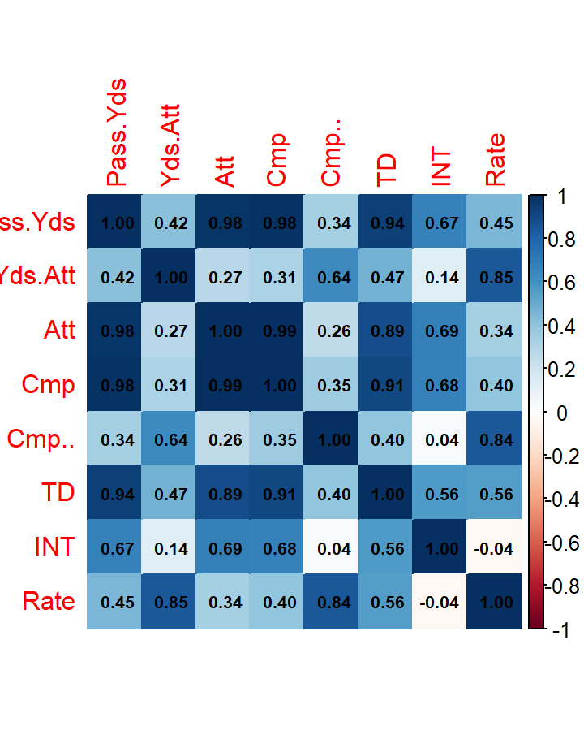

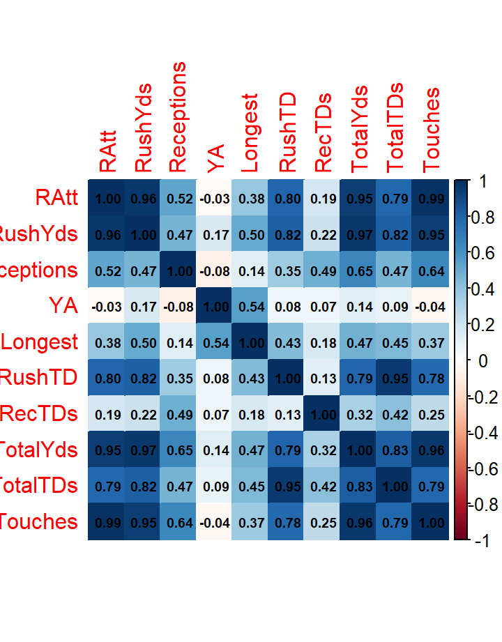

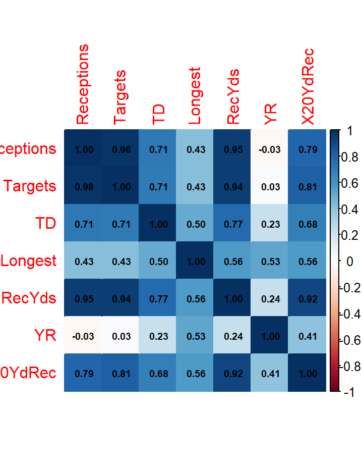

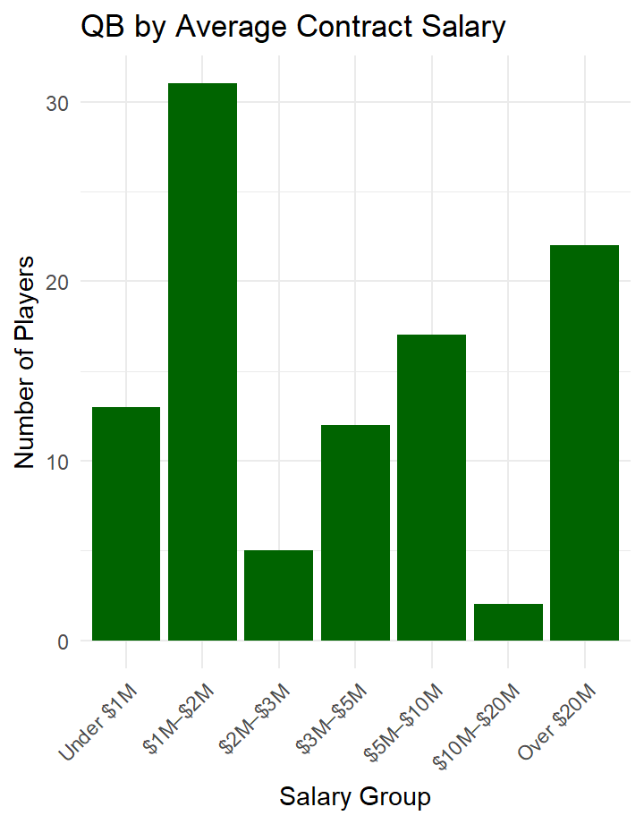

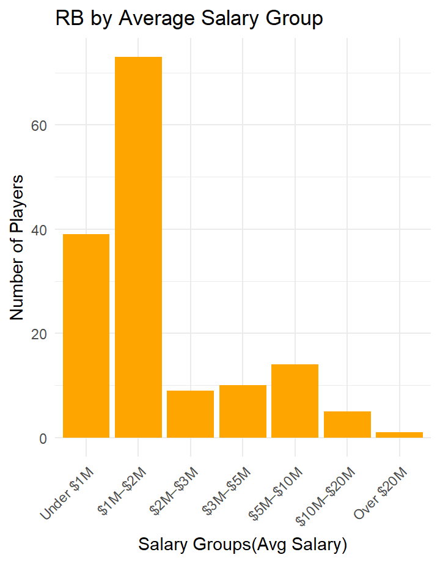

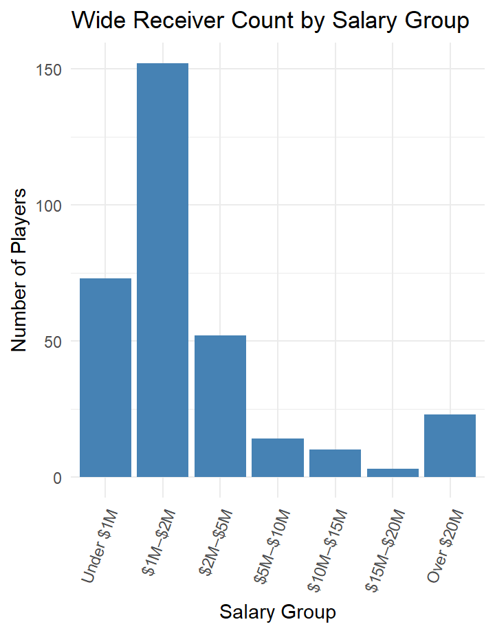

# Overview

### Background

The National Football League (NFL) is a multi-billion-dollar industry where player compensation is often viewed as a reflection of performance, marketability, and team needs. However, the precise relationship between player performance and salary, particularly among offensive players, remains a topic of ongoing debate. This study investigates the correlations between offensive player metrics — such as yards gained, touchdowns scored, and other key performance indicators — and their corresponding salaries. The study will also be broken down by posistion for fair assessments. By analyzing data across multiple seasons, the study aims to identify trends that appear to influence the market. Understanding these correlations can provide valuable insights for teams, agents, and players navigating contract negotiations in a highly competitive environment.

### Research Questions

- “What statistics most directly correlate with an NFL player’s salary?”
- “What offensive skill position seems to be the most undercompensated, in comparison to the others?”
- Additionally, this study will analyze the correlation between players’ ages and their salaries. All of the study will be conducted on the top 50-60% at each position group statistically. Offensive Line & TE will not be included in the study.

# Data & Variables

### Data

|  | Player | Pass.Yds | Yds.Att | Att | Cmp | Cmp.. | TD | INT | Rate | X1st | X1st. | X20..YD.Pass | X40..YD.Pass | Longest.Pass | Sck | SckY | Rank | Pos | Team.Currently.With | Age.At.Signing | Start..Year | End.Year | Yrs | Value | Average.Salary | X..of.Cap.At.Sign | Current Age | RAtt | RushYds | … |
| --- | --- | --- | --- | --- | --- | --- | --- | --- | --- | --- | --- | --- | --- | --- | --- | --- | --- | --- | --- | --- | --- | --- | --- | --- | --- | --- | --- | --- | --- | --- |
| 1 | Joe Burrow | 4918 | 7.5 | 652 | 460 | 70.6 | 43 | 9 | 108.5 | 253 | 38.8 | 49 | 12 | 70 | 48 | 278 | T3 | QB | CIN CIN | 26 | 2023 | 2029 | 5 | 275000000 | 55000000 | 0.24 | 28 |  |  | … |
| 2 | Jared Goff | 4629 | 8.6 | 539 | 390 | 72.4 | 37 | 12 | 111.8 | 236 | 43.8 | 61 | 11 | 82 | 31 | 234 | 13 | QB | DET DET | 29 | 2024 | 2028 | 4 | 212000000 | 53000000 | 0.21 | 30 |  |  | … |
| 3 | Baker Mayfield | 4500 | 7.9 | 570 | 407 | 71.4 | 41 | 16 | 106.8 | 224 | 39.3 | 58 | 5 | 57 | 40 | 248 | 19 | QB | TB TB | 28 | 2024 | 2026 | 3 | 100000000 | 33333333 | 0.13 | 29 |  |  | … |
| 4 | Geno Smith | 4320 | 7.5 | 578 | 407 | 70.4 | 21 | 15 | 93.2 | 209 | 36.2 | 50 | 4 | 71 | 50 | 338 | 20 | QB | LV LV | 32 | 2023 | 2025 | 3 | 75000000 | 25000000 | 0.11 | 34 |  |  | … |
| 5 | Sam Darnold | 4319 | 7.9 | 545 | 361 | 66.2 | 35 | 12 | 102.5 | 207 | 38 | 62 | 10 | 97 | 48 | 335 | 18 | QB | SEA SEA | 27 | 2025 | 2027 | 3 | 100500000 | 33500000 | 0.12 | 27 |  |  | … |
| 6 | Lamar Jackson | 4172 | 8.8 | 474 | 316 | 66.7 | 41 | 4 | 119.6 | 198 | 41.8 | 56 | 14 | 84 | 23 | 149 | 6 | QB | BAL BAL | 26 | 2023 | 2027 | 5 | 260000000 | 52000000 | 0.23 | 28 |  |  | … |
| 7 | Patrick Mahomes | 3928 | 6.8 | 581 | 392 | 67.5 | 26 | 11 | 93.5 | 214 | 36.8 | 40 | 4 | 54 | 36 | 239 | 1 | QB | KC KC | 24 | 2020 | 2031 | 10 | 450000000 | 45000000 | 0.23 | 29 |  |  | … |
| 8 | Aaron Rodgers | 3897 | 6.7 | 584 | 368 | 63 | 28 | 11 | 90.5 | 192 | 32.9 | 51 | 7 | 71 | 40 | 302 | 17 | QB | NYJ NYJ | 39 | 2023 | 2025 | 3 | 112500000 | 37500000 | 0.17 | 41 |  |  | … |
| 9 | Justin Herbert | 3870 | 7.7 | 504 | 332 | 65.9 | 23 | 3 | 101.7 | 175 | 34.7 | 54 | 7 | 66 | 41 | 242 | 5 | QB | LAC LAC | 25 | 2023 | 2029 | 5 | 262500000 | 52500000 | 0.23 | 27 |  |  | … |
| 10 | Brock Purdy | 3864 | 8.5 | 455 | 300 | 65.9 | 20 | 12 | 96.1 | 178 | 39.1 | 56 | 11 | 76 | 31 | 153 | 66 | QB | SF SF | 22 | 2022 | 2025 | 4 | 3737008 | 934252 | 0 | 25 |  |  | … |

[output cut: 242 more lines]

### Variables Used & What they mean

- Player: The name of the athlete being measured.
- Att: A forward pass thrown by the quarterback, regardless of whether it is completed, incomplete, or intercepted.
- Passing Yards: The total number of yards gained by a quarterback through completed forward passes.
- Yards per Attempt (Y/A): The average number of passing yards gained per passing attempt, calculated by dividing total passing yards by total pass attempts.
- Completions: The number of passes successfully caught by a receiver from the quarterback.
- Completion Percentage: The percentage of passing attempts that result in a completion, calculated by dividing completions by attempts and multiplying by 100.
- TD (Touchdown Passes): The number of passes thrown by the quarterback that directly result in a touchdown.
- INT (Interceptions): The number of passes thrown by the quarterback that are caught by the opposing team’s defense.
- Passer Rating: A formula-based statistic that measures a quarterback’s overall passing performance, factoring in completion percentage, yards per attempt, touchdowns, and interceptions.
- YR (Yards per Reception) A calculation of a players total receiving yards, by the number of receptions
- RAtt (Rushing Attempts): The number of rushing attempts a player has (running plays).
- RushYds (Rushing Yards): The total yards gained on rushing attempts.
- YA (Yards per Attempt): Average yards gained per rushing attempt.
- Longest: The longest single rushing play in yards.
- TwentyYdRush: Number of rushing plays that gained 20 or more yards.
- RushTD (Rushing Touchdowns): Total touchdowns scored via rushing plays.
- Receptions: Number of times the player caught a pass.
- Targets: The number of times a pass was thrown in the player’s direction.
- RecYards (Receiving Yards): Total yards gained on receptions.
- YR (Yards per Reception): Average yards gained per catch.
- RecTDs (Receiving Touchdowns): Total touchdowns scored on receptions.
- FumblesLost: Number of times the player fumbled the ball and the opposing team recovered.
- TotalYds (Total Yards): Combined rushing and receiving yards.
- TotalTDs (Total Touchdowns): Combined rushing and receiving touchdowns.
- Touches: Combined total of rushing attempts and receptions (Att + Receptions).
- YR (Yards per Reception): Average yards gained per catch.
- Longest: Longest single reception by the player in yards.
- X20YdRec (20+ Yard Receptions): Number of receptions gaining 20 or more yards.
- TD (Touchdowns): Number of receiving touchdowns.
- Age: Player’s age.
- TotalValue: Total dollar value of the player’s contract.
- AvgYear (Average Yearly Salary): Annual average salary from the contract.

# QB

### QB Salary & Passing Yards

[interactive chart not shown]

### QB Salary & Passer Rating

[interactive chart not shown]

### QB Salary & Passing Touchdowns

[interactive chart not shown]

### QB Salary & Passing Completions

[interactive chart not shown]

### QB Salary & Passing Interceptions

[interactive chart not shown]

### QB Salary & Completion Percentage

[interactive chart not shown]

### Corrleogram

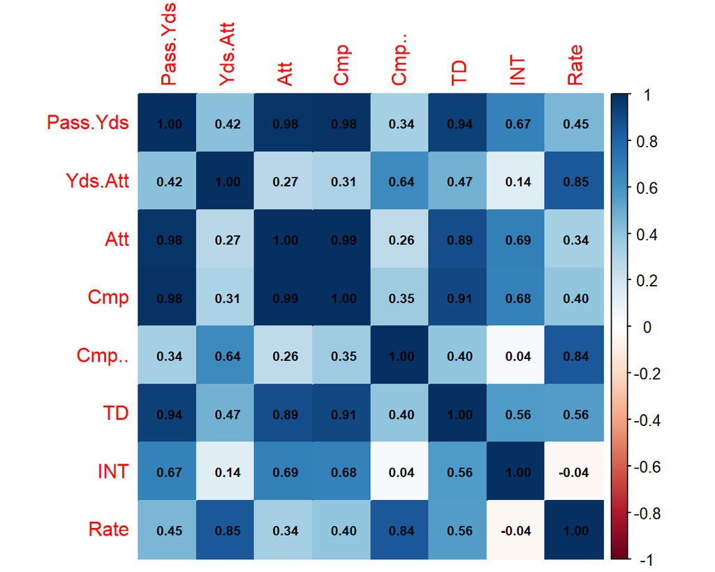

Analysis

The stat that correlates the most with Salary is Passing Yards, even though it correlates the most, there are still a lot of outliers, whether it be to the player being young, or hurt, or just not playing to potential. Total amount of Completions also tells a similar story, wiht majority of the QBs that throw more than 200 completions are paid well. No other graph though tells a similar story to these two.

# RB

### RB Salary & Rushing Attempts

[interactive chart not shown]

### RB Salary & Rushing Yds

[interactive chart not shown]

### RB Salary & Rushing TDs

[interactive chart not shown]

### RB Salary & Total Yards

[interactive chart not shown]

### RB Salary & Total Touchdowns

[interactive chart not shown]

### RB Salary & Touches

[interactive chart not shown]

### Corrleogram

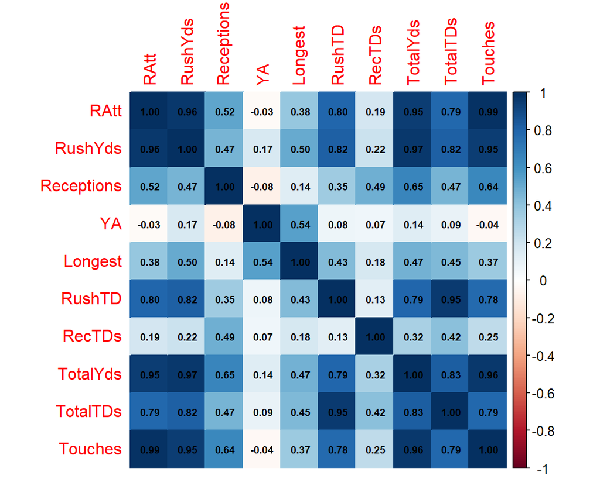

Analysis

The stat that seems to correlate the most with an increase in Salary is Rushing Yards and/or total yards. This makes sense because this is the main stat that is measured for running backs. There are a good amount of outliers though with a lot of Rushing Yards but aren’t paid much, because they are younger players.

# WR

### WR Salary & TDs

[interactive chart not shown]

### WR Salary & Receptions

[interactive chart not shown]

### WR Salary & Recieving Yards

[interactive chart not shown]

### WR Salary & 20 Yard Receptions

[interactive chart not shown]

### Correlogram

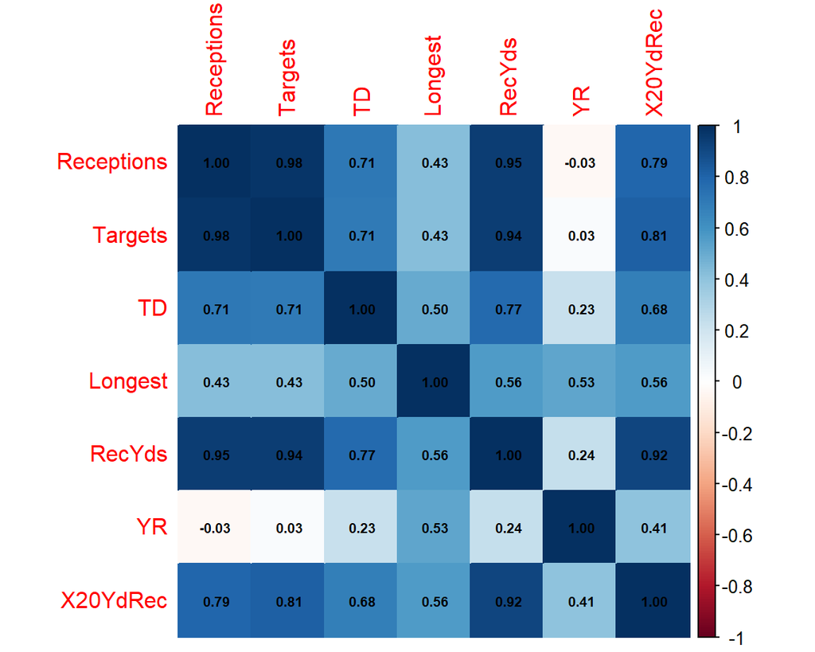

Analysis

Majority of the statistics for WRs are cut and dry, and more of said stat usually means more money. Many of the Players that seem to be outliers are still playing on rookie contracts, meaning they are still being paid as if they were recently drafted, but those that seem to follow the positive, linear trend aren’t on their 1st contrcats.

# Salary Groups

### QB Salary Groups

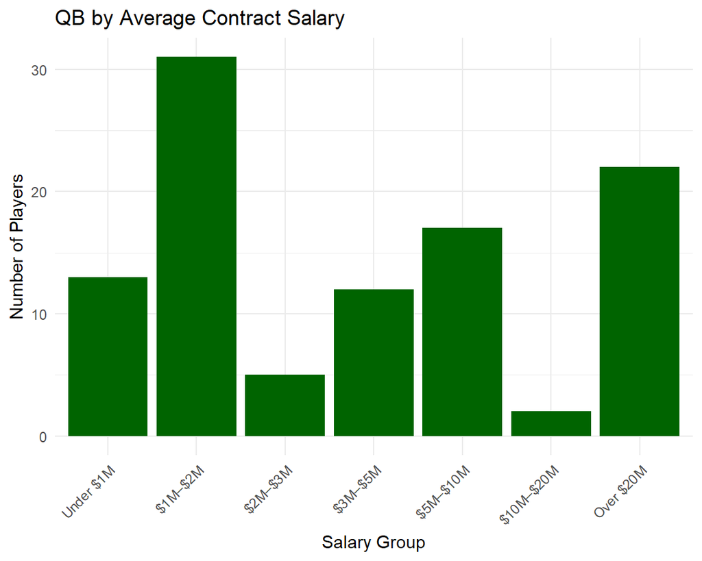

### RB Salary Groups

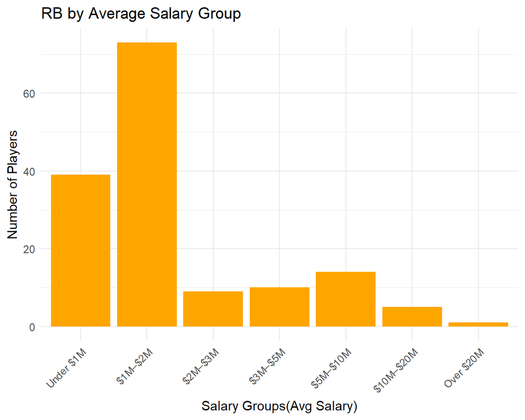

### WR Salary Groups

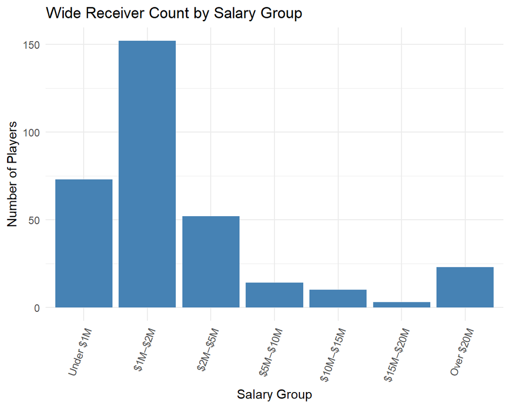

Analysis

It is clear that the quarterback is paid the most, but between wide receivers and running backs, despite there being a much higher number of WRs, they are still paid much more on average than RBs

# Salary by Age

### QB

[interactive chart not shown]

### RB

[interactive chart not shown]

### WR

[interactive chart not shown]

# Conclusion

### Limitations

There weren’t many limitations to this project outside of obtaining the data itself, some websites don’t allow data extraction without payment, or the data may not have extracted in a manner that could be used. The sites used were also live sites, so players that are not currently on a team but were during the 24-25 season appeared with no salary information initially because at this point in the year, they’ve entered free agency. Another limitation of the project, or something that slowed me down was different displays of player names, so that required some manual cleaning as well.

### References

Spotrac Contract Information Database [https://www.spotrac.com/]

FantasyPros [https://www.fantasypros.com/]

NFL.com [https://www.nfl.com/]

Over The Cap [https://overthecap.com/]

### Conclusion

In conclusion, it was blatant that the Quarterbacks are the skill players on offense that bring home the most money, and WRs are in a not super close, 2nd place. And RBs are last, which isn’t due to usefulness or utility, but rather the longevity of careers. Not many RBs make it past year 3-4 to get the proper payment that reflects their plat, but WRs and QBs do tend to make it out of the rookie contract and play long after. During the process to figure out which position was the most under compensated on offense, the statistics that are determining factors of salary were also discovered.

# About

My name is Rashaad Glenn, I am a Sophomore Mechical Engineering student with a Minor in Data analytics. I chose this topic because football was one of my first loves and the reason that I came to college, so combining two things I love, football and math was a great oppurtunity to explore some things I was curious about. Later this year I will begin a role at Ge Aerospace, as I hope to become a Mechanical Engineer for defense vehicles in the future.

````r
---
title: "NFL Offense Salary Exploration"
author: "Rashaad Glenn"
output:
  flexdashboard::flex_dashboard:
    orientation: columns
    vertical_layout: fill
    source_code: embed
---

```{r setup, include=FALSE}
library(flexdashboard)
library(pacman)
library(ggrepel)
library(plotly)
library(ggrepel)
library(corrgram)
library(corrplot)
library(flexdashboard)
library(DT)
library(tidyverse)
library(data.table)
p_load(tidyverse)

QBCI<- read.csv("Contract Info.csv")
QBStat<- read.csv("QBStat.csv")
QBCI <- QBCI %>%mutate(`Current Age` = Age.At.Signing + (2025 - Start..Year))
QBData<- QBStat%>%left_join(QBCI, by="Player")

RBStat<- read.csv("RunningBackStats.csv")
RBContract<- read.csv("RBContract.csv")
RBData<- RBStat%>%left_join(RBContract, by="Player" )

WRCI<- read.csv("WRContract.csv")
WRStats<- read.csv("WRStats.csv")
WRData<- WRStats%>%left_join(WRCI, by="Player")
```

Overview
===

Column {width=450}
---------------------------------------------------

### Background
The National Football League (NFL) is a multi-billion-dollar industry where player compensation is often viewed as a reflection of performance, marketability, and team needs. However, the precise relationship between player performance and salary, particularly among offensive players, remains a topic of ongoing debate. This study investigates the correlations between offensive player metrics — such as yards gained, touchdowns scored, and other key performance indicators — and their corresponding salaries. The study will also be broken down by posistion for fair assessments. By analyzing data across multiple seasons, the study aims to identify trends that appear to influence the market. Understanding these correlations can provide valuable insights for teams, agents, and players navigating contract negotiations in a highly competitive environment.


Column {width=450}
---------------------------------------------------

### Research Questions
- “What statistics most directly correlate with an NFL player’s salary?”
- “What offensive skill position seems to be the most undercompensated, in comparison to the others?”

- Additionally, this study will analyze the correlation between players' ages and their salaries. All of the study will be conducted on the top 50-60% at each position group statistically. Offensive Line & TE will not be included in the study.

Data & Variables
===

Column{.tabset data-width=450}
---
### Data
```{r show_table}
combined_table <- rbindlist(list(QBData, RBData, WRData), fill=TRUE)
datatable(combined_table)
```






Column{data-width=450}
---
### Variables Used & What they mean
- Player:
  The name of the athlete being measured.

- Att: A forward pass thrown by the quarterback, regardless of whether it is completed, incomplete, or intercepted.

- Passing Yards:
  The total number of yards gained by a quarterback through completed forward passes.

- Yards per Attempt (Y/A):
  The average number of passing yards gained per passing attempt, calculated by dividing total passing yards by total pass attempts.

- Completions:
  The number of passes successfully caught by a receiver from the quarterback.

- Completion Percentage:
  The percentage of passing attempts that result in a completion, calculated by dividing completions by attempts and multiplying by 100.

- TD (Touchdown Passes):
  The number of passes thrown by the quarterback that directly result in a touchdown.

- INT (Interceptions):
  The number of passes thrown by the quarterback that are caught by the opposing team's defense.

- Passer Rating:
  A formula-based statistic that measures a quarterback’s overall passing performance, factoring in completion percentage, yards per attempt, touchdowns, and interceptions.

- YR (Yards per Reception)
  A calculation of a players total receiving yards, by the number of receptions

- RAtt (Rushing Attempts):
  The number of rushing attempts a player has (running plays).

- RushYds (Rushing Yards):
The total yards gained on rushing attempts.

- YA (Yards per Attempt):
  Average yards gained per rushing attempt.

- Longest:
  The longest single rushing play in yards.

- TwentyYdRush: Number of rushing plays that gained 20 or more yards.

- RushTD (Rushing Touchdowns):
  Total touchdowns scored via rushing plays.

- Receptions:
  Number of times the player caught a pass.

- Targets:
  The number of times a pass was thrown in the player's direction.

- RecYards (Receiving Yards):
  Total yards gained on receptions.

- YR (Yards per Reception):
  Average yards gained per catch.

- RecTDs (Receiving Touchdowns):
  Total touchdowns scored on receptions.

- FumblesLost:
  Number of times the player fumbled the ball and the opposing team recovered.

- TotalYds (Total Yards):
  Combined rushing and receiving yards.

- TotalTDs (Total Touchdowns):
  Combined rushing and receiving touchdowns.

- Touches:
  Combined total of rushing attempts and receptions (Att + Receptions).

- YR (Yards per Reception):
  Average yards gained per catch.

- Longest:
  Longest single reception by the player in yards.

- X20YdRec (20+ Yard Receptions):
  Number of receptions gaining 20 or more yards.

- TD (Touchdowns):
  Number of receiving touchdowns.

- Age:
  Player’s age.

- TotalValue:
  Total dollar value of the player's contract.

- AvgYear (Average Yearly Salary):
  Annual average salary from the contract.


QB
===
Column {.tabset data-width=600}
--------

### QB Salary & Passing Yards
```{r}
QBSalaryPassYds<- ggplot(QBData, aes(x=Pass.Yds, y=Average.Salary, text=Player, color=Player ))+
  geom_point()
ggplotly(QBSalaryPassYds)
```

### QB Salary & Passer Rating
```{r}
SalaryPsrRate<- ggplot(QBData, aes(x=Rate, y=Average.Salary, text=Player, color=Player))+
  geom_point()
ggplotly(SalaryPsrRate)
```

### QB Salary & Passing Touchdowns
```{r}
QBSalaryPassTDs<- ggplot(QBData, aes(x=TD , y=Average.Salary, text=Player, color=Player ))+
  geom_point()
ggplotly(QBSalaryPassTDs )
```

### QB Salary & Passing Completions
```{r}
QBSalaryCmps<- ggplot(QBData, aes(x=Cmp , y=Average.Salary, text=Player, color=Player ))+
  geom_point()
ggplotly(QBSalaryCmps )
```
````

````r
### QB Salary & Passing Interceptions
```{r}
QBSalaryINT<-ggplot(QBData, aes(x=INT , y=Average.Salary, text=Player, color=Player ))+
  geom_point()
ggplotly(QBSalaryINT )
```


### QB Salary & Completion Percentage
```{r}
QBSalaryCmpsPerc<- ggplot(QBData, aes(x=Cmp.. , y=Average.Salary, text=Player, color=Player ))+
  geom_point()
ggplotly(QBSalaryCmpsPerc )
```

### Corrleogram
```{r}
corQB<- cor(QBData[c("Pass.Yds", "Yds.Att", "Att", "Cmp","Cmp.." ,"TD", "INT", "Rate")])
corrplot(corQB, method = "color", addCoef.col = "black", number.cex= 0.65)
```


Column {.tabset data-width=300}
---
Analysis

The stat that correlates the most with Salary is Passing Yards, even though it correlates the most, there are still a lot of outliers, whether it be to the player being young, or hurt, or just not playing to potential. Total amount of Completions also tells a similar story, wiht majority of the QBs that throw more than 200 completions are paid well. No other graph though tells a similar story to these two.



RB
===
Column {.tabset data-width=600}
--------

### RB Salary & Rushing Attempts
```{r}
RBAttSal<- ggplot(RBData, aes(x=RAtt , y=Avg..Year, text=Player, color=Player))+ geom_point()
ggplotly(RBAttSal)
```

### RB Salary & Rushing Yds
```{r}
RBRydSal<- ggplot(RBData, aes(x=RushYds , y=Avg..Year, text=Player, color=Player))+ geom_point()
ggplotly(RBRydSal)
```

### RB Salary & Rushing TDs
```{r}
RBRTDSal<- ggplot(RBData, aes(x=RushTD , y=Avg..Year, text=Player, color=Player))+ geom_point()
ggplotly(RBRTDSal)
```

### RB Salary & Total Yards
```{r}
RBTYSal<- ggplot(RBData, aes(x=TotalYds , y=Avg..Year, text=Player, color=Player))+ geom_point()
ggplotly(RBTYSal)
```

### RB Salary & Total Touchdowns
```{r}
RBTTD<- ggplot(RBData, aes(x=TotalTDs , y=Avg..Year, text=Player, color=Player))+ geom_point()
ggplotly(RBTTD)
```


### RB Salary & Touches
```{r}
RBT<- ggplot(RBData, aes(x=Touches, y=Avg..Year, text=Player, color=Player))+ geom_point()
ggplotly(RBT)
```

### Corrleogram
```{r}
corRB<- cor(RBData[c("RAtt", "RushYds", "Receptions", "YA", "Longest", "RushTD", "RecTDs", "TotalYds", "TotalTDs", "Touches" )])
corrplot(corRB, method = "color", addCoef.col = "black", number.cex = 0.6)
```

Column {.tabset data-width=300}
---
Analysis

The stat that seems to correlate the most with an increase in Salary is Rushing Yards and/or total yards. This makes sense because this is the main stat that is measured for running backs. There are a good amount of outliers though with a lot of Rushing Yards but aren't paid much, because they are younger players.

WR
===
Column {.tabset data-width=600}
--------

### WR Salary & TDs

```{r}
WRTD<- ggplot(WRData, aes(x=TD , y=AvgYear, text=Player, color=Player))+ geom_point()
ggplotly(WRTD)
```

### WR Salary & Receptions
```{r}
WRRec<- ggplot(WRData, aes(x=Receptions , y=AvgYear, text=Player, color=Player))+ geom_point()
ggplotly(WRRec)
```

### WR Salary & Recieving Yards
```{r}
WRYds<- ggplot(WRData, aes(x=RecYds , y=AvgYear, text=Player, color=Player))+ geom_point()
ggplotly(WRYds)
```


### WR Salary & 20 Yard Receptions
```{r}
WR20<- ggplot(WRData, aes(x=X20YdRec , y=AvgYear, text=Player, color=Player))+ geom_point()
ggplotly(WR20)
```

### Correlogram
```{r}
corWR<- cor(WRData[c("Receptions", "Targets", "TD" ,"Longest", "RecYds", "YR", "X20YdRec" )])
corrplot(corWR, method = "color", addCoef.col = "black", number.cex = 0.6)
```

Column {.tabset data-width=300}
---
Analysis

Majority of the statistics for WRs are cut and dry, and more of said stat usually means more money. Many of the Players that seem to be outliers are still playing on rookie contracts, meaning they are still being paid as if they were recently drafted, but those that seem to follow the positive, linear trend aren't on their 1st contrcats.


Salary Groups
===

Column {.tabset data-width=700}
---

### QB Salary Groups
```{r}
QBsalary_bins <- c(0, 1e6, 2e6, 3e6, 5e6, 10e6, 20e6, Inf)
QBsalary_labels <- c("Under $1M", "$1M–$2M", "$2M–$3M", "$3M–$5M", "$5M–$10M", "$10M–$20M", "Over $20M")

QBCIdf <- QBCI %>%
  mutate(QBSalaryGroup = cut(Average.Salary, breaks = QBsalary_bins,
                           labels = QBsalary_labels, right = FALSE))

QBsalary_counts <- QBCIdf %>%
  count(QBSalaryGroup)

QBCon<- ggplot(QBsalary_counts, aes(x = QBSalaryGroup, y = n)) +
  geom_bar(stat = "identity", fill = "darkgreen") +
  labs(title = "QB by Average Contract Salary",
       x = "Salary Group",
       y = "Number of Players") +
  theme_minimal() +
  theme(axis.text.x = element_text(angle = 45, hjust = 1))

QBCon
```

### RB Salary Groups
```{r}
RBsalary_bins <- c(0, 1e6, 2e6, 3e6, 5e6, 10e6, 20e6, Inf)
RBsalary_labels <- c("Under $1M", "$1M–$2M", "$2M–$3M", "$3M–$5M", "$5M–$10M", "$10M–$20M", "Over $20M")

RBdf <- RBContract %>%
  mutate(RBSalaryGroup = cut(Avg..Year , breaks = RBsalary_bins, labels = RBsalary_labels, right = FALSE))

RBsalary_counts <- RBdf %>%
  count(RBSalaryGroup)

RBCon<- ggplot(RBsalary_counts, aes(x = RBSalaryGroup, y = n)) +
  geom_bar(stat = "identity", fill = "orange") +
  labs(title = "RB by Average Salary Group",
       x = "Salary Groups(Avg Salary)",
       y = "Number of Players") +
  theme_minimal() +
  theme(axis.text.x = element_text(angle = 45, hjust = 1))

RBCon
```

### WR Salary Groups
```{r}
WRsalary_bins <- c(0, 1e6, 2e6, 5e6, 10e6, 15e6, 20e6, Inf)
WRsalary_labels <- c("Under $1M", "$1M–$2M", "$2M–$5M", "$5M–$10M",
                   "$10M–$15M", "$15M–$20M", "Over $20M")
WRContract <- WRCI %>%
  mutate(SalaryGroup = cut(AvgYear, breaks = WRsalary_bins, labels = WRsalary_labels, right = FALSE))

salary_counts <- WRContract %>%
  count(SalaryGroup)

WRBar<- ggplot(salary_counts, aes(x = SalaryGroup, y = n)) +
  geom_bar(stat = "identity", fill = "steelblue") +
  labs(title = "Wide Receiver Count by Salary Group",
       x = "Salary Group",
       y = "Number of Players") +
  theme_minimal() +
  theme(axis.text.x = element_text(angle = 70, hjust = 1))
WRBar
```

Column {.tabset data-width=200}
------
Analysis
````

````r
It is clear that the quarterback is paid the most, but between wide receivers and running backs, despite there being a much higher number of WRs, they are still paid much more on average than RBs


Salary by Age
===
Column {.tabset data-width=650}
------
### QB
```{r}
QBage_bins <- c(20, 25, 28, 30, 32, 34, 45)
QBage_labels <- c("21–25", "26–28", "29–30", "31–32", "33–34", "35+")
QBContract <- QBData %>%
  mutate(AgeGroup = cut(`Current Age`, breaks = QBage_bins, labels = QBage_labels, right = TRUE))

QBBox<- ggplot(QBContract, aes(x = AgeGroup, y = Average.Salary)) +
  geom_boxplot(fill = "red", color = "red") +
  labs(title = "QB Salaries by Age Group",
       x = "Age Group",
       y = "Average Yearly Salary (USD)") +
  theme_minimal()

ggplotly(QBBox)
```


### RB
```{r}
RBage_bins <- c(20, 22, 24, 26, 28, 30, 35)
RBage_labels <- c("21–22", "23–24", "25–26", "27–28", "29–30", "31–34")

RBCI <- RBData %>%
  mutate(AgeGroup = cut(Age, breaks = RBage_bins, labels = RBage_labels, right = TRUE))

RBAgeCon<- ggplot(RBCI, aes(x = AgeGroup, y = Avg..Year)) +
  geom_boxplot(fill = "#012199", color = "#012199") +
  labs(title = "RB Salaries by Age Group",
       x = "Age Group",
       y = "Average Yearly Salary (USD)") +
  theme_minimal()
ggplotly(RBAgeCon)
```

### WR
```{r}
WRage_bins <- c(20, 24, 26, 28, 30, 32, 36)
WRage_labels <- c("21–24", "25–26", "27–28", "29–30", "31–32", "33+")

WRContract <- WRCI %>%
  mutate(AgeGroup = cut(Age, breaks = WRage_bins, labels = WRage_labels, right = TRUE))

WRAgeCon<- ggplot(WRContract, aes(x = AgeGroup, y = AvgYear)) +
  geom_boxplot(fill = "orchid", color = "black") +
  labs(title = "Wide Receiver Salary by Age Group",
       x = "Age Group",
       y = "Average Yearly Salary (USD)") +
  theme_minimal()
ggplotly(WRAgeCon)
```

Conclusion
===

Column {data-width=500}
---

### Limitations
There weren't many limitations to this project outside of obtaining the data itself, some websites don't allow data extraction without payment, or the data may not have extracted in a manner that could be used. The sites used were also live sites, so players that are not currently on a team but were during the 24-25 season appeared with no salary information initially because at this point in the year, they've entered free agency. Another limitation of the project, or something that slowed me down was different displays of player names, so that required some manual cleaning as well.


### References
Spotrac Contract Information Database [https://www.spotrac.com/]

FantasyPros [https://www.fantasypros.com/]

NFL.com [https://www.nfl.com/]

Over The Cap [https://overthecap.com/]

Column {data-width=500}
---

### Conclusion
In conclusion, it was blatant that the Quarterbacks are the skill players on offense that bring home the most money, and WRs are in a not super close, 2nd place. And RBs are last, which isn't due to usefulness or utility, but rather the longevity of careers. Not many RBs make it past year 3-4 to get the proper payment that reflects their plat, but WRs and QBs do tend to make it out of the rookie contract and play long after. During the process to figure out which position was the most under compensated on offense, the statistics that are determining factors of salary were also discovered.

About
===
My name is Rashaad Glenn, I am a Sophomore Mechical Engineering student with a Minor in Data analytics. I chose this topic because football was one of my first loves and the reason that I came to college, so combining two things I love, football and math was a great oppurtunity to explore some things I was curious about. Later this year I will begin a role at Ge Aerospace, as I hope to become a Mechanical Engineer for defense vehicles in the future.
````